# Modelos Lineares Generalizados

Joseferson da Silva barreto e Antonio Victor

2022-09-30

# Objetivo

Objetivo é executar uma analise afim de buscar relações entre as variáveis e conseguir um melhor ajuste para fazer determinadas predições , para esta análise vamos utilizar o pacote RStanArm e o software Rstúdio

# Metodologia

para está análise utilizaremos o pacote ** RStanArm** e o banco de dados **forestfires** contendo informações relevantes sobre íncendios ocorridos na aréa do parque natural Montesesinho Bragança(portugal) , este conjunto de dados contém 517 observações.

Variáveis:

# introdução

Os modelos lineares Generalizados são utilizados quando utilizar os modelos clássicos que pressupoem que os dados seguem uma distribuição normal e principalmente onde temos dados que segue uma base de dados discretos . O princípio do GLM é pegar uma família de distribuições ao ínves de uma única distribuição que no nosso caso será a famíla exponencial , ou sejá , ao ínves de trabalhar apenas com a normal , trabalhamos com várias distribuições : gamma,expenencial,poisson ,binomial,binomial negativa,weibell

Um estudo de regressão busca,essencialmente,associar uma variável **Y** (denominada variável dependente)a uma outra variável **X** (denominada variável explanatória ou variável independente ).

## Partes de um MLG

1. $Y_{i} \sim p(y | \theta) \rightarrow E(y_{i}) = \mu_{i}$
2. $n_{i} = g(\mu_{i})$
3. $n_{i} = \beta_{0} + \beta_{1} *x_{I}$

# Conhecendo o Nossos Dados

## Análise Exploratória

O ponta pé inicial de qualquer análise é a análise exploratória, com ela começas a entender a grandeza dos nossos dados e os seus comportamentos, dessa forma, vamos carregar os pacotes necessários e executar a análise exploratória:

```r
library(tidyverse)
library(DT)
library(readxl)


dados<-read.csv("forestfires.csv",sep = ",")
```

Vamos verificar se nosso conjunto de dados pussui valores ausentes, caso tenhamos, teremos que remover essas observações

```r
sum(dados[!complete.cases(dados),])
```

```
## [1] 0
```

Como podemos ver o nosso conjunto de dados não apresentou nenhum valor faltante, logo, podemos prosseguir da forma que está.

### Observando a Grandeza dos Nossos dados

Para verificar a grandeza dos nossos dados vamos utilizar o seguinte comando:

```r
glimpse(dados)
```

```
## Rows: 517
## Columns: 13
## $ X     <int> 7, 7, 7, 8, 8, 8, 8, 8, 8, 7, 7, 7, 6, 6, 6, 6, 5, 8, 6, 6, 6, 5…
## $ Y     <int> 5, 4, 4, 6, 6, 6, 6, 6, 6, 5, 5, 5, 5, 5, 5, 5, 5, 5, 4, 4, 4, 4…
## $ month <chr> "mar", "oct", "oct", "mar", "mar", "aug", "aug", "aug", "sep", "…
## $ day   <chr> "fri", "tue", "sat", "fri", "sun", "sun", "mon", "mon", "tue", "…
## $ FFMC  <dbl> 86.2, 90.6, 90.6, 91.7, 89.3, 92.3, 92.3, 91.5, 91.0, 92.5, 92.5…
## $ DMC   <dbl> 26.2, 35.4, 43.7, 33.3, 51.3, 85.3, 88.9, 145.4, 129.5, 88.0, 88…
## $ DC    <dbl> 94.3, 669.1, 686.9, 77.5, 102.2, 488.0, 495.6, 608.2, 692.6, 698…
## $ ISI   <dbl> 5.1, 6.7, 6.7, 9.0, 9.6, 14.7, 8.5, 10.7, 7.0, 7.1, 7.1, 22.6, 0…
## $ temp  <dbl> 8.2, 18.0, 14.6, 8.3, 11.4, 22.2, 24.1, 8.0, 13.1, 22.8, 17.8, 1…
## $ RH    <int> 51, 33, 33, 97, 99, 29, 27, 86, 63, 40, 51, 38, 72, 42, 21, 44, …
## $ wind  <dbl> 6.7, 0.9, 1.3, 4.0, 1.8, 5.4, 3.1, 2.2, 5.4, 4.0, 7.2, 4.0, 6.7,…
## $ rain  <dbl> 0.0, 0.0, 0.0, 0.2, 0.0, 0.0, 0.0, 0.0, 0.0, 0.0, 0.0, 0.0, 0.0,…
## $ area  <dbl> 0, 0, 0, 0, 0, 0, 0, 0, 0, 0, 0, 0, 0, 0, 0, 0, 0, 0, 0, 0, 0, 0…
```

Como podemos ver a maioria das variáveis já estão no formato adequado,mas ainda teremos que tratar duas variáveis: **Month,Day** essas variáveis estão no formato texto ,vamos converte-las para fator

### Transformações de Variáveis

```r
 dados$month<-factor(dados$month,levels = c("jan","feb","mar","apr","may","jun","jul","aug","sep","oct","nov","dec"),labels = c("1","2","3","4","5","6","7","8","9","10","11","12"))



dados$day<-factor(dados$day,levels=c("sun","mon","tue","wed",
            "thu","fri","sat"),labels = c("1","2","3","4","5","6","7"))
```

Com nossas variáveis devidamente ordenadas transformadas em fatores podemos converte-las para númericas,ou seja” por exemplo , iremos cronologicamente trabalahar com a variável **day** ,considerando: dia 1 , dia 2 ,dia 3 e assim sucessivamente. O mesmo pensamento vale para a variável **month** onde iremos considerar: mês 1 ,mês 2 , mês 3 ….

Observação:  
esse tipo de conversão não muda a grandeza de nossos dados , tendo em vista que a escala de medida é de uma únidade para **day** e **month** logo, o delta será uma unidade em cada mês e para a variável **day**, será uma unidade para cada dia. Nesse sentido , a correlação irá pegar se na escala ta crescendo ou decrescendo a medida que a outra variável se altera , logo podemos fazer está conversão.

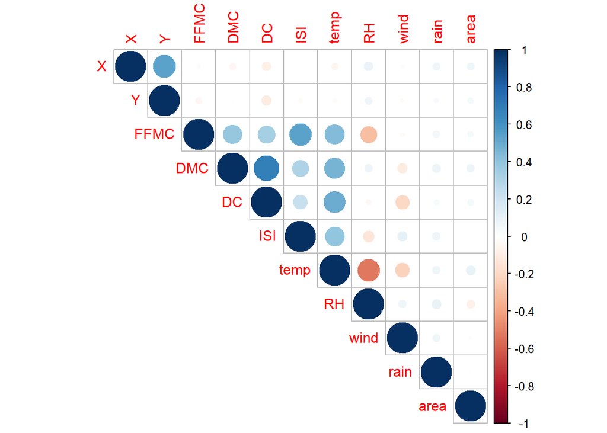

```r
dados$day<-as.numeric(dados$day)

dados$month<-as.numeric(dados$month)






corrplot::corrplot(cor(dados[-3:-4]),type = "upper")
```

```r
#library(dataMaid)
#dataMaid::makeDataReport(dados, output = 'html')

#help(makeDataReport)
```

```r
library(dlookr)

eda_report(dados, "area", output_format = "html",browse = FALSE,output_dir = "C:/Users/joseferson/Documents/joseferson barreto/projeto_MLG")
```

```r
library(knitr)
# Primeiro pacote: dataMaid
#library(dataMaid)
#dados<-py$pdados
#dataMaid::makeDataReport(dados, output = "HTML")
knitr::include_url("EDA_Report.html",height = '500')
```

[interactive chart not shown]

## seleção de Atributos

Por que selecionar atributos?

Dentre os atributos, existem aquelas onde as informações contidas vão importar mais para o problema que você deseja resolver.

Mas por que existe essa diferença? Existem vários fatores que podem influenciar nessa questão, sendo os mais comuns:

1- Muitos dados faltantes naquela coluna, impossibilitando qualquer conclusão. Exemplo: Mais da metade das células em branco/vazias em uma coluna determinada.

2- Colunas com alta correlação entre si. Exemplo: Se estou trabalhando com colunas de carros, tendo uma coluna a quantidade de rodas e outra correspondente a quantidade de eixos no carro, temos uma correspondente total, pois cada eixo, há exatamente duas rodas. Assim, ao fazer essas análises, existem duas variáveis redundantes, aumentando a quantidade de dados a serem processados.

3- Muitos atributos. É ainda que na sua base de dados a ser trabalhada, existe um grande número de colunas, passando das milhares, ou mesmo, como em mais colunas do que alinhadas. Assim, haverá um grande custo de processamento, selecionar quais atributos deveríamos nos atentar,ajuda a minimizar este custo.

Aplicando o método de seleção de atributos